# Fase 4 — Notebook integrador: análisis, reproducibilidad y comunicación de resultados

**Proyecto:** Grupo 3 · MCDI500 · **Dataset:** Siniestros de tipo atropello 2023 (CONASET / Carabineros de Chile)

**Pregunta del proyecto:** ¿qué factores de la vía, del entorno y del contexto del siniestro se asocian con que un atropello resulte con al menos un fallecido?

Este notebook integra las cuatro fases y se ejecuta de principio a fin con *Restart Kernel and Run All Cells*:

| Fase | Qué aporta | Dónde está |
| --- | --- | --- |
| F1 | Problema, entorno y reconocimiento del dato | `F1/F1_Definicion.ipynb` |
| F2 | Obtención, limpieza y variables nuevas | `F2/src/` |
| F3 | Corrección de la hora y mediciones de eficiencia | `F3/src/` |
| F4 | Clases de medición, pruebas, visualizaciones | `F4/src/`, `F4/tests/` |

Se ejecuta desde la carpeta `F4/`. El CSV crudo no está versionado: ver el README para obtenerlo y verificar su huella.

## 1. Configuración y verificación del entorno

```python
import sys
from pathlib import Path

import matplotlib
import numpy as np
import pandas as pd
import seaborn as sns
import sklearn

for ruta in ("../F2/src", "../F3/src", "src"):          # módulos de cada fase
    sys.path.insert(0, str(Path(ruta).resolve()))

import mediciones
import pipeline
import visualizacion

visualizacion.configurar_tema()
print("Python:", sys.version.split()[0])
print("pandas:", pd.__version__, "| NumPy:", np.__version__, "| scikit-learn:", sklearn.__version__)
print("Matplotlib:", matplotlib.__version__, "| seaborn:", sns.__version__)
print("Entorno virtual activo:", sys.prefix != sys.base_prefix)

Path("resultados").mkdir(exist_ok=True)           # evidencia versionada del entorno y de las mediciones
Path("figuras").mkdir(exist_ok=True)
Path("resultados/entorno.txt").write_text(
    f"python={sys.version.split()[0]}\npandas={pd.__version__}\nnumpy={np.__version__}\n"
    f"scikit-learn={sklearn.__version__}\nmatplotlib={matplotlib.__version__}\nseaborn={sns.__version__}\n"
    f"venv_activo={sys.prefix != sys.base_prefix}\n", encoding="utf-8")
```

```
Python: 3.13.15
pandas: 3.0.5 | NumPy: 2.5.3 | scikit-learn: 1.9.1
Matplotlib: 3.11.2 | seaborn: 0.13.2
Entorno virtual activo: True
```

```
109
```

```python
RUTA_CRUDO = Path("../F1/data/raw/Atropellos_2023.csv")
huella = pipeline.huella_sha256(RUTA_CRUDO)
print("SHA-256 del dato crudo:", huella)
print("Coincide con el dato de origen documentado:", huella == pipeline.HUELLA_SHA256)
```

```
SHA-256 del dato crudo: 96c94c37a1472d595a6da1b53310a53eeb12c8b4f9419dab586fed832cdca553
Coincide con el dato de origen documentado: True
```

## 2. Fases 1 a 3 integradas: del dato crudo al conjunto preparado

`pipeline.preparar_dataset()` encadena las funciones ya existentes: `obtencion.cargar_crudo` → `verificar_esquema` → `limpieza.limpiar_datos` → `transformacion.generar_nuevas_variables` → `pipeline.corregir_hora`.

**Corrección heredada de la Fase 3.** `Hora_limpia` quedó en 0 en las 5.541 filas de la Fase 2 porque se calculó desde `Hora`, que en el archivo original vale lo mismo en todas las filas. La hora real está en `Hora_texto`. Se corrige acá, sin modificar F2, y la prueba de regresión comprueba que ninguna otra columna cambia.

```python
df = pipeline.preparar_dataset(RUTA_CRUDO)

assert df.shape[0] == 5541, "El pipeline perdió o duplicó filas"
assert int(df["Es_Fatal"].sum()) == 407, "Cambió la cantidad de casos fatales"
print("Filas:", df.shape[0], "· columnas:", df.shape[1])
print(f"Casos fatales: {int(df['Es_Fatal'].sum())} ({df['Es_Fatal'].mean():.2%})")

blancos = {c: int((df[c].astype(str).str.strip() == "").sum()) for c in pipeline.COLUMNAS_TEXTO}
print("Celdas en blanco tras la limpieza:", blancos)
assert sum(blancos.values()) == 0
```

```
Filas: 5541 · columnas: 44
Casos fatales: 407 (7.35%)
Celdas en blanco tras la limpieza: {'Ruta': 0, 'Calle_Uno': 0, 'Calle_Dos': 0, 'Intersecci': 0, 'Condición': 0, 'Ubicación': 0}
```

```python
import limpieza, obtencion, transformacion

previo = transformacion.generar_nuevas_variables(limpieza.limpiar_datos(obtencion.cargar_crudo(RUTA_CRUDO)))
print("Hora_limpia en la Fase 2 -> valores distintos:", previo["Hora_limpia"].nunique(), "| valores:", previo["Hora_limpia"].unique())
print("Hora_limpia corregida   -> valores distintos:", df["Hora_limpia"].nunique(), "| rango:", df["Hora_limpia"].min(), "a", df["Hora_limpia"].max())
assert df["Hora_limpia"].between(0, 23).all()
```

```
Hora_limpia en la Fase 2 -> valores distintos: 1 | valores: [0]
Hora_limpia corregida   -> valores distintos: 24 | rango: 0 a 23
```

## 3. Preprocesamiento: dos conjuntos con propósitos distintos

El conjunto que sirve para modelar no sirve para graficar: con *one hot* las categorías pasan a columnas de ceros y unos y con el escalamiento los valores pierden su unidad. Por eso se conservan dos versiones:

- **`visual`**: copia interpretable, con categorías y unidades originales (hora en horas, zona y causa con su nombre).
- **Matriz de análisis**: partición estratificada 80/20 con `random_state=42`; el escalador y el codificador se **ajustan solo con entrenamiento** y se aplican a prueba, para evitar fuga de datos.

```python
visual = pipeline.construir_df_visual(df)
A_tr, A_te, y_tr, y_te, nombres = pipeline.construir_matriz_analisis(df)

print("Para visualizar:", visual.shape, "| columnas:", list(visual.columns))
print("Para análisis  : entrenamiento", A_tr.shape, "| prueba", A_te.shape, "| columnas:", len(nombres))
assert not (np.isnan(A_tr).any() or np.isnan(A_te).any()), "La matriz tiene nulos"
assert A_tr.shape[1] == A_te.shape[1] == len(nombres)
print(f"Proporción de fatales: entrenamiento {y_tr.mean():.2%} · prueba {y_te.mean():.2%}")
visual.head()
```

```
Para visualizar: (5541, 7) | columnas: ['Zona', 'Dia_semana', 'Estado_Atm', 'Hora_limpia', 'Es_Fatal', 'Causa', 'Tramo_horario']
Para análisis  : entrenamiento (4432, 28) | prueba (1109, 28) | columnas: 28
Proporción de fatales: entrenamiento 7.36% · prueba 7.30%
```

|  | Zona | Dia_semana | Estado_Atm | Hora_limpia | Es_Fatal | Causa | Tramo_horario |
| --- | --- | --- | --- | --- | --- | --- | --- |
| 0 | Urbana | Sábado | NUBLADO | 19 | 1 | Alcohol en conductor | 18-21 h |
| 1 | Rural | Miércoles | NEBLINA | 6 | 1 | Imprudencia del peatón | 06-11 h |
| 2 | Urbana | Domingo | DESPEJADO | 5 | 1 | Imprudencia del peatón | 00-05 h |
| 3 | Urbana | Domingo | LLUVIA | 2 | 0 | Alcohol en conductor | 00-05 h |
| 4 | Urbana | Domingo | DESPEJADO | 22 | 0 | Imprudencia del peatón | 22-23 h |

## 4. Eficiencia: tres comparaciones con clases `Medicion` (patrón Strategy)

`Medicion` es la clase base; cada hija declara solo su entrada y sus dos estrategias (`version_a`, `version_b`). Cada comparación verifica primero que A y B entreguen el mismo resultado y luego mide **tiempo** (mínimo de 7 repeticiones, `timeit`) y **memoria pico** (`tracemalloc`) sobre **tamaños crecientes**. El exponente *k* de la relación t ≈ c·nᵏ se estima con la pendiente log-log (`numpy.polyfit`).

```python
N = len(df)
corridas = [
    mediciones.MedicionHora([500, 1000, 2500, N]),
    mediciones.MedicionBusqueda([500, 1000, 2500, N]),
    mediciones.MedicionRecorrido([1000, 5000, 20000]),
]
tablas = []
for medicion in corridas:                    # polimorfismo: la misma llamada para las tres
    tabla = medicion.ejecutar(df)
    tablas.append(tabla)
    k = medicion.exponentes()
    print(f"{medicion.nombre}: A = {medicion.etiqueta_a} | B = {medicion.etiqueta_b}")
    print(f"  exponente empírico  k_A = {k['k_a']:.2f}   k_B = {k['k_b']:.2f}")
resumen = pd.concat(tablas, ignore_index=True)
resumen.to_csv("resultados/mediciones.csv", index=False)
resumen.round(5)
```

```
Hora del siniestro: A = bucle con strptime | B = pd.to_datetime vectorizada
  exponente empírico  k_A = 0.99   k_B = 0.20
```

```
Fatales por comuna: A = filtrar cada vez | B = agrupar una vez
  exponente empírico  k_A = 0.37   k_B = 0.32
```

```
Recorrido de carpetas: A = rglob + filtro | B = recursiva con poda
  exponente empírico  k_A = 0.55   k_B = 0.00
```

|  | medicion | n | tiempo_a_s | tiempo_b_s | razon_tiempo | memoria_a_mb | memoria_b_mb | razon_memoria |
| --- | --- | --- | --- | --- | --- | --- | --- | --- |
| 0 | Hora del siniestro | 500 | 0.00310 | 0.00117 | 2.65395 | 0.00567 | 0.01265 | 0.44798 |
| 1 | Hora del siniestro | 1000 | 0.00608 | 0.00212 | 2.86619 | 0.01009 | 0.02093 | 0.48210 |
| 2 | Hora del siniestro | 2500 | 0.01517 | 0.00170 | 8.91604 | 0.02123 | 0.09189 | 0.23104 |
| 3 | Hora del siniestro | 5541 | 0.03306 | 0.00222 | 14.88417 | 0.04662 | 0.18309 | 0.25463 |
| 4 | Fatales por comuna | 500 | 0.11538 | 0.00054 | 213.16387 | 0.08527 | 0.03119 | 2.73396 |
| 5 | Fatales por comuna | 1000 | 0.17126 | 0.00063 | 271.41842 | 0.08351 | 0.05506 | 1.51664 |
| 6 | Fatales por comuna | 2500 | 0.22505 | 0.00082 | 276.00738 | 0.09579 | 0.11169 | 0.85761 |
| 7 | Fatales por comuna | 5541 | 0.28674 | 0.00119 | 241.87732 | 0.15895 | 0.22123 | 0.71851 |
| 8 | Recorrido de carpetas | 1000 | 0.04720 | 0.00150 | 31.47420 | 1.29950 | 0.00718 | 181.03135 |
| 9 | Recorrido de carpetas | 5000 | 0.06303 | 0.00146 | 43.06821 | 6.41026 | 0.00718 | 893.00478 |
| 10 | Recorrido de carpetas | 20000 | 0.25429 | 0.00151 | 168.58446 | 25.61282 | 0.00720 | 3556.74573 |

```python
for tabla, medicion in zip(tablas, corridas):
    ultima = tabla.iloc[-1]
    print(f"[{medicion.nombre}] con n = {int(ultima['n']):,}: "
          f"B es {ultima['razon_tiempo']:.1f} veces más rápida; "
          f"memoria A = {ultima['memoria_a_mb']:.3f} MB, B = {ultima['memoria_b_mb']:.3f} MB "
          f"(razón A/B = {ultima['razon_memoria']:.2f}).")
    invertidos = tabla.loc[tabla["razon_tiempo"] < 1, "n"].tolist()
    if invertidos:
        print(f"   En n = {invertidos} la versión A resultó más rápida (costo fijo de B).")
    else:
        print("   B fue más rápida en todos los tamaños medidos.")
```

```
[Hora del siniestro] con n = 5,541: B es 14.9 veces más rápida; memoria A = 0.047 MB, B = 0.183 MB (razón A/B = 0.25).
   B fue más rápida en todos los tamaños medidos.
[Fatales por comuna] con n = 5,541: B es 241.9 veces más rápida; memoria A = 0.159 MB, B = 0.221 MB (razón A/B = 0.72).
   B fue más rápida en todos los tamaños medidos.
[Recorrido de carpetas] con n = 20,000: B es 168.6 veces más rápida; memoria A = 25.613 MB, B = 0.007 MB (razón A/B = 3556.75).
   B fue más rápida en todos los tamaños medidos.
```

## 5. Visualizaciones analíticas

Hilo narrativo: **contexto** (cuántos atropellos hay y a qué hora se vuelven letales), **contraste** (qué causas concentran la letalidad) y **resolución** (si el efecto horario se mantiene al separar por zona). Se usan **tasas con su n** y no cifras absolutas, porque los grupos son de tamaños muy distintos y el 7,35 % de casos fatales hace que los conteos engañen.

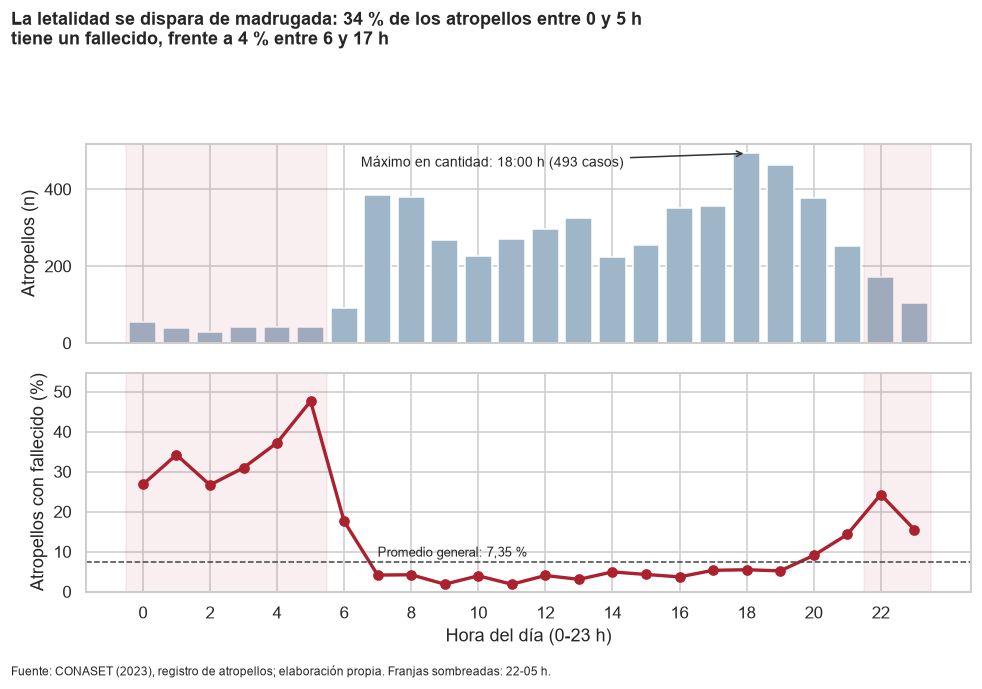

```python
fig1 = visualizacion.figura_hora(visual)
fig1.savefig("figuras/fig1_hora.png", dpi=170, bbox_inches="tight")
```

```python
por_hora = visual.groupby("Hora_limpia")["Es_Fatal"].agg(n="size", tasa="mean")
pico = por_hora["n"].idxmax()
mad = visual.loc[visual["Hora_limpia"].between(0, 5), "Es_Fatal"]
dia = visual.loc[visual["Hora_limpia"].between(6, 17), "Es_Fatal"]
print(f"Qué muestra : la mayor cantidad de atropellos ocurre a las {pico}:00 h ({int(por_hora.loc[pico, 'n'])} casos), "
      f"pero la letalidad es de {mad.mean():.1%} entre 0 y 5 h (n={len(mad)}) y de {dia.mean():.1%} entre 6 y 17 h (n={len(dia)}).")
print("Qué infiero : el momento con más atropellos no es el de mayor riesgo de muerte; la madrugada concentra pocos casos pero muy graves.")
print("Límite      : no hay datos de flujo de peatones ni vehículos por hora, así que no se puede hablar de riesgo por exposición.")
```

```
Qué muestra : la mayor cantidad de atropellos ocurre a las 18:00 h (493 casos), pero la letalidad es de 33.9% entre 0 y 5 h (n=251) y de 4.2% entre 6 y 17 h (n=3431).
Qué infiero : el momento con más atropellos no es el de mayor riesgo de muerte; la madrugada concentra pocos casos pero muy graves.
Límite      : no hay datos de flujo de peatones ni vehículos por hora, así que no se puede hablar de riesgo por exposición.
```

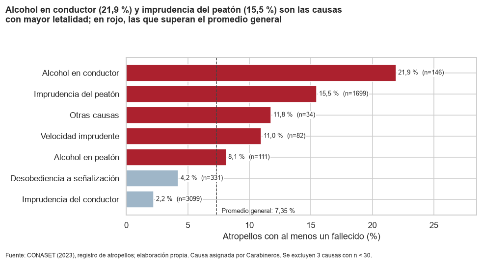

```python
fig2 = visualizacion.figura_causa(visual)
fig2.savefig("figuras/fig2_causa.png", dpi=170, bbox_inches="tight")
```

```python
tc = pipeline.tasa_fatalidad(visual, "Causa")
print(tc.round(1).to_string(index=False))
print("\nQué muestra : la letalidad varía mucho según la causa asignada; las dos mayores superan el doble del promedio general.")
print("Qué infiero : la gravedad se asocia más a quién y a qué condición originó el atropello que a su frecuencia.")
print("Límite      : la causa la asigna Carabineros (atribución, no medición) y se excluyen las causas con n < 30.")
```

```
                       Causa    n  fatales  tasa
        Alcohol en conductor  146       32  21.9
      Imprudencia del peatón 1699      263  15.5
                Otras causas   34        4  11.8
        Velocidad imprudente   82        9  11.0
           Alcohol en peatón  111        9   8.1
Desobediencia a señalización  331       14   4.2
   Imprudencia del conductor 3099       69   2.2

Qué muestra : la letalidad varía mucho según la causa asignada; las dos mayores superan el doble del promedio general.
Qué infiero : la gravedad se asocia más a quién y a qué condición originó el atropello que a su frecuencia.
Límite      : la causa la asigna Carabineros (atribución, no medición) y se excluyen las causas con n < 30.
```

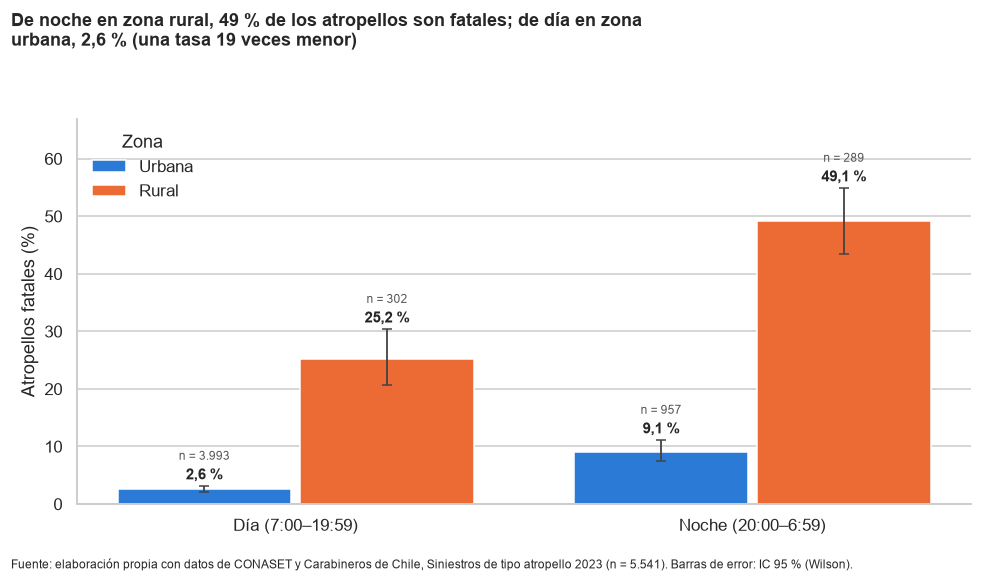

```python
fig3 = visualizacion.figura_zona_jornada(visual)
fig3.savefig("figuras/fig3_zona_jornada.png", dpi=170, bbox_inches="tight")
```

```python
tzj = pipeline.tasa_zona_jornada(visual)
print(tzj.round(1).to_string(index=False))
zona = visual.groupby("Zona")["Es_Fatal"].agg(n="size", fatales="sum", tasa="mean")
zona["tasa"] = (zona["tasa"] * 100).round(1)
print("\nTasa de fatalidad por zona:")
print(zona.to_string())
print("\nQué muestra : dentro de cada zona, la noche (20:00-6:59) tiene más letalidad que el día, y los intervalos de confianza no se solapan.")
print("Qué infiero : el efecto nocturno no se explica solo por ser zona rural; se mantiene al estratificar.")
print("Límite      : es una asociación observacional; no se controlan velocidad, iluminación ni consumo de alcohol, y no establece causalidad.")
```

```
  Zona            Jornada    n  fatales  tasa  inf  sup
 Rural   Día (7:00–19:59)  302       76  25.2 20.6 30.4
 Rural Noche (20:00–6:59)  289      142  49.1 43.4 54.9
Urbana   Día (7:00–19:59) 3993      102   2.6  2.1  3.1
Urbana Noche (20:00–6:59)  957       87   9.1  7.4 11.1

Tasa de fatalidad por zona:
           n  fatales  tasa
Zona
Rural    591      218  36.9
Urbana  4950      189   3.8

Qué muestra : dentro de cada zona, la noche (20:00-6:59) tiene más letalidad que el día, y los intervalos de confianza no se solapan.
Qué infiero : el efecto nocturno no se explica solo por ser zona rural; se mantiene al estratificar.
Límite      : es una asociación observacional; no se controlan velocidad, iluminación ni consumo de alcohol, y no establece causalidad.
```

## 6. Validación técnica: pruebas de casos normales, límite y excepciones

Las pruebas viven en `F4/tests/test_pipeline.py` y se ejecutan acá mismo, de modo que el resultado queda como evidencia en el notebook ejecutado y en su exportación a HTML.

```python
import subprocess

resultado = subprocess.run([sys.executable, "-m", "unittest", "discover", "-s", "tests", "-v"],
                           capture_output=True, text=True)
print(resultado.stderr)
assert resultado.returncode == 0, "Alguna prueba falló: revisar el detalle de arriba"
```

[output not shown]

## 7. Conclusiones y limitaciones

- **Hallazgos.** La letalidad de los atropellos depende de cuándo y dónde ocurren: se concentra en la madrugada y en zona rural, y el efecto nocturno se mantiene dentro de cada zona. Las causas atribuidas al alcohol del conductor y a la imprudencia del peatón presentan las tasas más altas.
- **Eficiencia.** En las tres comparaciones se verificó primero la equivalencia de resultados; las razones de tiempo y memoria se leen en la tabla de la sección 4, que se genera en cada ejecución.
- **Limitaciones.** Un solo año (2023); posible subregistro de fallecidos posteriores a 48 h; causa asignada por Carabineros; sin datos de exposición; asociaciones no causales.
- **Mejoras propuestas.** Incorporar más años para estabilizar las tasas de los grupos pequeños; modelar la probabilidad de fatalidad con regresión logística usando la matriz de análisis ya preparada; incluir variables de exposición (flujo vehicular y peatonal).